```python
!pip install --upgrade plotly
!pip install --upgrade pandas_profiling
```

[output not shown]

# **ID - 207043951**

# **Kaggle Site - https://www.kaggle.com/dorirosen**

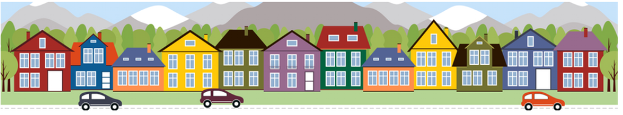

# TL;DR

In this exercise i will try to solve the Kaggle contest "House Prices - Advanced Regression Techniques"

i will need to predict house prices in Ames, Iowa, according to vast variety of 80 features.

In order to do that i will need to analyze the data so i could find a connections between house features and its predicted price.

i will pick the best features for my modle and i will perform cross validation and i will perform ML regression on the data.

# imports and defines

```python
import math
import numpy as np
import pandas as pd
import seaborn as sns
import matplotlib.pyplot as plt
import warnings
warnings.filterwarnings("ignore", message="Feature names only support names that are all strings")
# sklearn imports
import sklearn
from sklearn import metrics,datasets,pipeline,linear_model,preprocessing,model_selection

from sklearn.preprocessing import OrdinalEncoder,OneHotEncoder,LabelEncoder,StandardScaler,MinMaxScaler

from sklearn.model_selection import train_test_split , KFold , LeavePOut,RepeatedKFold , GridSearchCV

from sklearn.linear_model import LinearRegression , SGDRegressor

from sklearn.compose import make_column_transformer

from tqdm.auto import tqdm

from sklearn.metrics import mean_squared_error

from sklearn.feature_selection import RFECV

import plotly.graph_objects as go
import plotly.express as px

# define plt settings
sns.set_theme()
plt.rcParams["font.size"] = 20
plt.rcParams["axes.labelsize"] = 20
plt.rcParams["xtick.labelsize"] = 20
plt.rcParams["ytick.labelsize"] = 20
plt.rcParams["legend.fontsize"] = 20
plt.rcParams["legend.markerscale"] = 1.5
plt.rcParams["figure.figsize"] = (20, 10)
plt.rcParams["legend.title_fontsize"] = 20
```

```python
with open('/kaggle/input/task2-dorirose/data_description.txt', 'r') as file:
  # Read the contents of the file
  contents = file.read()
  # Print the contents
  print(contents)
```

```
MSSubClass: Identifies the type of dwelling involved in the sale.

        20	1-STORY 1946 & NEWER ALL STYLES
        30	1-STORY 1945 & OLDER
        40	1-STORY W/FINISHED ATTIC ALL AGES
        45	1-1/2 STORY - UNFINISHED ALL AGES
        50	1-1/2 STORY FINISHED ALL AGES
        60	2-STORY 1946 & NEWER
        70	2-STORY 1945 & OLDER
        75	2-1/2 STORY ALL AGES
        80	SPLIT OR MULTI-LEVEL
        85	SPLIT FOYER
        90	DUPLEX - ALL STYLES AND AGES
       120	1-STORY PUD (Planned Unit Development) - 1946 & NEWER
       150	1-1/2 STORY PUD - ALL AGES
       160	2-STORY PUD - 1946 & NEWER
       180	PUD - MULTILEVEL - INCL SPLIT LEV/FOYER
       190	2 FAMILY CONVERSION - ALL STYLES AND AGES

MSZoning: Identifies the general zoning classification of the sale.

       A	Agriculture
       C	Commercial
       FV	Floating Village Residential
       I	Industrial
       RH	Residential High Density
       RL	Residential Low Density
       RP	Residential Low Density Park
       RM	Residential Medium Density

LotFrontage: Linear feet of street connected to property

LotArea: Lot size in square feet

Street: Type of road access to property

       Grvl	Gravel
       Pave	Paved

Alley: Type of alley access to property
```

[output cut: 468 more lines]

```
       COD	Court Officer Deed/Estate
       Con	Contract 15% Down payment regular terms
       ConLw	Contract Low Down payment and low interest
       ConLI	Contract Low Interest
       ConLD	Contract Low Down
       Oth	Other

SaleCondition: Condition of sale

       Normal	Normal Sale
       Abnorml	Abnormal Sale -  trade, foreclosure, short sale
       AdjLand	Adjoining Land Purchase
       Alloca	Allocation - two linked properties with separate deeds, typically condo with a garage unit
       Family	Sale between family members
       Partial	Home was not completed when last assessed (associated with New Homes)
```

# Load The Data

```python
def readData():
    b = pd.read_csv('/kaggle/input/task2-dorirose/train.csv')
    b.replace('', np.NaN, inplace=True)
    return b

def Drop(data,columns):
    data.drop(columns, axis=1,inplace = True)
df = readData()
#dropping Id because it wont help us
Drop(df,'Id')
```

# EDA

Now I will try and explore the data.

First, I will see explanations on every feature.

And then I will view the keys to get a fast overview of the features I will see,

I will also use heat map to see the corralation of the features.

# Functions

- **count empty values**
- **active fill data**
- **get objects columns from data**
- **Outliers Functions**

```python
def count_empty_values_in_each_column(d: pd.DataFrame):
    print('empty values')
    print('------------\n')

    empty_columns = []
    for col in d.columns:
        empty = d[col].isna().sum()
        if empty != 0:
            empty_columns.append(col)
            print(f"{col}: {empty}")
    return empty_columns

def fill_na_median(x, column_names):
    for column_name in column_names:
        x[column_name].fillna(x[column_name].median(),inplace = True)

def fill_na_mean(x, column_names):
    for column_name in column_names:
        x[column_name].fillna(x[column_name].mean(),inplace = True)

def fill_na_mode(df, column_names):
    for column_name in column_names:
        df[column_name].fillna(df[column_name].mode()[0], inplace=True)

def getObjects(data):
    return data.select_dtypes('object').columns

def outliers_iqr(ys):# gets numric column and return indexs in array
    quartile_1, quartile_3 = np.percentile(ys, [25, 75]) #Get 1st and 3rd quartiles (25% -> 75% of data will be kept)
    iqr = quartile_3 - quartile_1
    lower_bound = quartile_1 - (iqr * 1.5) #Get lower bound
    upper_bound = quartile_3 + (iqr * 1.5) #Get upper bound
    return np.where((ys > upper_bound) | (ys < lower_bound)) #Get outlier values

def DropOutliers(data):# need to do : x = thefunction
    for column in data:
        outlierValuesList = np.ndarray.tolist(outliers_iqr(data[column])[0]) #outliers_iqr() returns an array
    return data.drop(outlierValuesList) #Drop outlier rows

def getOutliers(data):# need to do : x = thefunction
    for column in data:
        outlierValuesList = np.ndarray.tolist(outliers_iqr(data[column])[0]) #outliers_iqr() returns an array
    return outlierValuesList
```

# Functions for finding what to drop

- **Dealing with NULL values**
- **Distinct catagories fall into same catagories.**
- **features that are correlated to each other**
- **not Correlated With the target**

```python
#Dealing with NULL values
def dropColumnsMoreThen_Nan(data):
    data.dropna(axis=1, how='any', thresh = 1000,inplace = True) #Drop columns that contain more than 40% NULL values

# dropping Distinct catagories fall into same catagories.
def dropDistinctOnThreshold(data, valThreshold):
    number_of_rows = len(data)
    drop_list = []
    for col in data.columns:
        highest_freq_val = data[col].mode()[0]
        appearance_num = (data[col] == highest_freq_val).sum()
        if (appearance_num / number_of_rows) > valThreshold:
            drop_list.append(col)
    return drop_list


#Drop features that are correlated to each other
def FeaturesCorrelatedToEachOther(data):
    covarianceMatrix = data.corr()
    listOfFeatures = [i for i in covarianceMatrix]
    setOfDroppedFeatures = set()
    for i in range(len(listOfFeatures)) :
        for j in range(i+1,len(listOfFeatures)): #Avoid repetitions
            feature1=listOfFeatures[i]
            feature2=listOfFeatures[j]
            if abs(covarianceMatrix[feature1][feature2]) > 0.8: #If the correlation between the features is > 0.8
                setOfDroppedFeatures.add(feature1) #Add one of them to the set
                                                   #I tried different values of threshold and 0.8 was the one that gave the best results
    return setOfDroppedFeatures

def nonCorrelatedWithOutput(data):
    nonCorrelatedWithOutput = [column for column in data if abs(data[column].corr(data["SalePrice"])) < 0.045]
    #I tried different values of threshold and 0.045 was the one that gave the best results
    return nonCorrelatedWithOutput
```

# Functions For Visualization Things

```python
# display heatmap of train
def displayHeatMap(data):
    plt.figure(figsize=(48,46))
    cor = abs(data.corr())
    sns.heatmap(cor, annot=True, cmap="YlGnBu", vmin=0, vmax=1,mask=np.triu(cor))
    plt.show()

def firstLookAtData(data):
    sns.heatmap(data.isnull(),yticklabels=False,cbar=False)


def showPlotOfNanDataMoreThenThirdPrecentOfData(data):
    number = len(data)/3
    features = []
    nullValues = []
    for i in data:
        if (data.isna().sum()[i])>number and i!='SalePrice':
            features.append(i)
            nullValues.append(data.isna().sum()[i])
    y_pos = np.arange(len(features))
    plt.bar(y_pos, nullValues, align='center', alpha=0.5)
    plt.xticks(y_pos, features)
    plt.ylabel('NULL Values')
    plt.xlabel('Features')
    plt.title(f'Features with more than {number} NULL values')
    plt.show()


def show_accuracy_by_encoder(dfs, encoder_names):
    accuracy_df = pd.DataFrame(columns=['encoder_name', 'split', 'accuracy'])

    for i, df in enumerate(dfs):
        X = df.drop(['SalePrice'],axis=1)
        t = df['SalePrice']
        X_train, X_val, t_train, t_val = train_test_split(X, t, test_size=0.3, random_state=42)
        encoder_name = encoder_names[i]
        model = LinearRegression()
        model.fit(X_train, t_train)
        accuracy_df.loc[len(accuracy_df)] = [encoder_name, 'train', model.score(X_train, t_train)]
        accuracy_df.loc[len(accuracy_df)] = [encoder_name, 'val', model.score(X_val, t_val)]

    fig = px.bar(accuracy_df, x='encoder_name', y='accuracy', color='split', barmode='group')
    #img_bytes = fig.to_image(format="png", width=600, height=350, scale=2)
    display(fig)

def encode(df, columns_names, enc):
    df_cp = df.copy()
    feature_names = [str(name) for name in data_object]
    if enc == le:
        df_enc = df_cp.copy()
        for features in feature_names:
            df_enc[features] = le.fit_transform(df_cp[features].astype(str))
    else:
        df_cat = df_cp[columns_names]
        df_cat_enc = pd.DataFrame(enc.fit_transform(df_cat))
        df_enc = df_cp.drop(columns_names, axis=1).join(df_cat_enc)
    return df_enc
```

# First look at the data that shows count of null values Overall

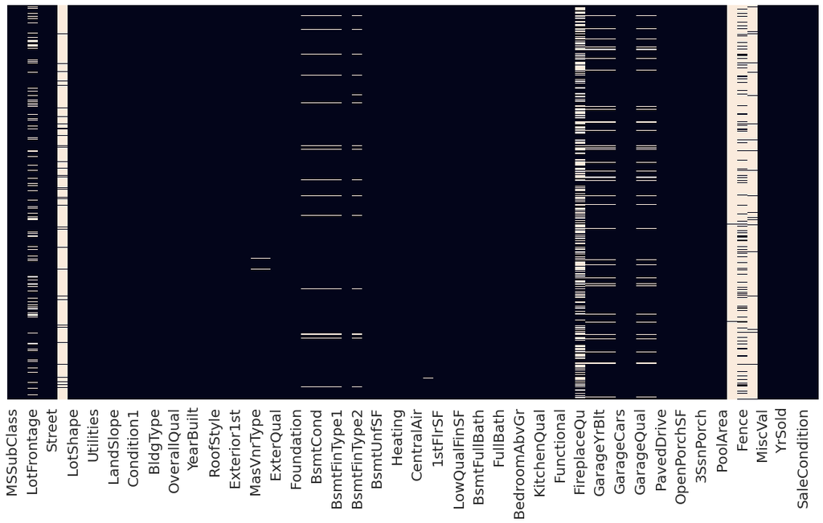

```python
firstLookAtData(df)
```

# House pricing report

```python
# House_pricing_report = sw.analyze(df)
# House_pricing_report.show_notebook(layout='vertical')
```

# conclusion from the report

Missing values in catagories:

1. **Alley- 1369/1460 rows missing**
2. **FireplaceQu- 690/1460 rows missing**
3. **PoolQc- 1453/1460 rows missing**
4. **Fence- 1179/1460 rows missing**
5. **MiscFeature- 1406/1460 rows missing**

# Let's illustrate the missing values and drop them

- Missing values param - thresh = 1000

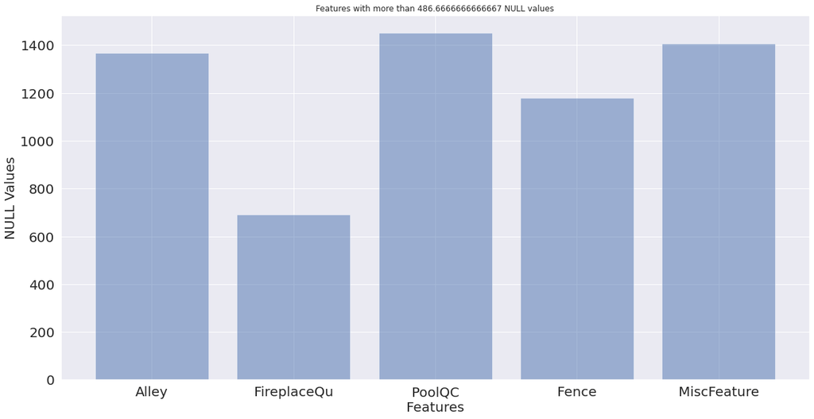

```python
showPlotOfNanDataMoreThenThirdPrecentOfData(df)
dropColumnsMoreThen_Nan(df)
```

# More conclusion from the report

distinct catagories( >=90% fall into same catagories):

1.**Street- 99% = 'Pave'.**

2.**LandContour- 90% = 'Lvl'.**

3.**Condition2- 99% = 'Norm'.**

4.**GarageQual- 95% = 'TA'.**

5.**GarageCond- 96% = 'TA'.**

6.**PavedDrive- 92% = 'Y'.**

7.**3SsnPorch- 98.4% = 0.**

8.**ScreenPorch- 92% = 0.**

9.**PoolArea- 99% = 0.**

10.**MiscVal- 96% = 0.**

11.**Utilities- 99% = 'AllPub'.**

12.**Heating- 99% = 'GasA'.**

# **as we can see :**

**the catagories is up then 90% fall into same catagories**

**just to make sure i will drop who has more then 85% that fall into same catagories.**

```python
D3 = dropDistinctOnThreshold(df,0.85)
# dropping Distinct catagories fall into same catagories.
Drop(df,D3)
```

# Fill data

```python
print(f'Before filling \n')
count_empty_values_in_each_column(df)

categorical_featuresTrain = ['MasVnrType', 'BsmtQual', 'BsmtExposure', 'BsmtFinType1', 'GarageType', 'GarageFinish']
categorical_featuresTest = ['MSZoning', 'Utilities', 'Exterior1st', 'Exterior2nd', 'MasVnrType', 'BsmtQual', 'BsmtCond', 'BsmtExposure', 'BsmtFinType1', 'BsmtFinType2', 'KitchenQual', 'Functional', 'GarageType', 'GarageFinish', 'GarageQual', 'GarageCond', 'SaleType']
fill_na_median(df, ['MasVnrArea', 'GarageYrBlt'])
fill_na_mean(df, ['LotFrontage'])
fill_na_mode(df, categorical_featuresTrain)
# fill_na_median(tf, ['BsmtFullBath', 'BsmtHalfBath', 'GarageYrBlt', 'GarageCars','MasVnrArea', 'GarageArea'])
# fill_na_mean(tf, ['LotFrontage', 'BsmtFinSF1', 'BsmtFinSF2', 'BsmtUnfSF', 'TotalBsmtSF'])
# fill_na_mode(tf, categorical_featuresTest)
print(f'After filling \n')
count_empty_values_in_each_column(df)
# x = count_empty_values_in_each_column(tf)
```

```
Before filling

empty values
------------

LotFrontage: 259
MasVnrType: 8
MasVnrArea: 8
BsmtQual: 37
BsmtExposure: 38
BsmtFinType1: 37
GarageType: 81
GarageYrBlt: 81
GarageFinish: 81
After filling

empty values
------------
```

```
[]
```

# Make all data to be numric

- first of all i will take all the object types from my data.
- then i will encode the data in three ways and i will try to find from a plot which is the best encoder for my training.

```python
data_object = getObjects(df)
de = OneHotEncoder(drop="first", sparse=False).fit(df[data_object])
oe = OrdinalEncoder().fit(df[data_object])
le = LabelEncoder()
encoder_names = ['Dummy Encoder', 'Ordinal Encoder', "Label Encoder"]

df_de = encode(df, data_object, de)
df_oe = encode(df, data_object, oe)
df_le = encode(df, data_object, le)
dfs = [df_de, df_oe, df_le]
show_accuracy_by_encoder(dfs, encoder_names)
```

[interactive chart not shown]

# conclusion from the plot

- as we can see , the dummy encoder give us the best accuracy., so i will change all my object data to be dummy encoded .

```python
x = data_object.tolist()
# Use get_dummies to dummy code the categorical columns
df_dummy = pd.get_dummies(df, columns=x, prefix=x,drop_first = True)
df_dummy
```

|  | MSSubClass | LotFrontage | LotArea | OverallQual | OverallCond | YearBuilt | YearRemodAdd | MasVnrArea | BsmtFinSF1 | BsmtUnfSF | ... | GarageType_BuiltIn | GarageType_CarPort | GarageType_Detchd | GarageFinish_RFn | GarageFinish_Unf | SaleCondition_AdjLand | SaleCondition_Alloca | SaleCondition_Family | SaleCondition_Normal | SaleCondition_Partial |
| --- | --- | --- | --- | --- | --- | --- | --- | --- | --- | --- | --- | --- | --- | --- | --- | --- | --- | --- | --- | --- | --- |
| 0 | 60 | 65.0 | 8450 | 7 | 5 | 2003 | 2003 | 196.0 | 706 | 150 | ... | 0 | 0 | 0 | 1 | 0 | 0 | 0 | 0 | 1 | 0 |
| 1 | 20 | 80.0 | 9600 | 6 | 8 | 1976 | 1976 | 0.0 | 978 | 284 | ... | 0 | 0 | 0 | 1 | 0 | 0 | 0 | 0 | 1 | 0 |
| 2 | 60 | 68.0 | 11250 | 7 | 5 | 2001 | 2002 | 162.0 | 486 | 434 | ... | 0 | 0 | 0 | 1 | 0 | 0 | 0 | 0 | 1 | 0 |
| 3 | 70 | 60.0 | 9550 | 7 | 5 | 1915 | 1970 | 0.0 | 216 | 540 | ... | 0 | 0 | 1 | 0 | 1 | 0 | 0 | 0 | 0 | 0 |
| 4 | 60 | 84.0 | 14260 | 8 | 5 | 2000 | 2000 | 350.0 | 655 | 490 | ... | 0 | 0 | 0 | 1 | 0 | 0 | 0 | 0 | 1 | 0 |
| ... | ... | ... | ... | ... | ... | ... | ... | ... | ... | ... | ... | ... | ... | ... | ... | ... | ... | ... | ... | ... | ... |
| 1455 | 60 | 62.0 | 7917 | 6 | 5 | 1999 | 2000 | 0.0 | 0 | 953 | ... | 0 | 0 | 0 | 1 | 0 | 0 | 0 | 0 | 1 | 0 |
| 1456 | 20 | 85.0 | 13175 | 6 | 6 | 1978 | 1988 | 119.0 | 790 | 589 | ... | 0 | 0 | 0 | 0 | 1 | 0 | 0 | 0 | 1 | 0 |
| 1457 | 70 | 66.0 | 9042 | 7 | 9 | 1941 | 2006 | 0.0 | 275 | 877 | ... | 0 | 0 | 0 | 1 | 0 | 0 | 0 | 0 | 1 | 0 |
| 1458 | 20 | 68.0 | 9717 | 5 | 6 | 1950 | 1996 | 0.0 | 49 | 0 | ... | 0 | 0 | 0 | 0 | 1 | 0 | 0 | 0 | 1 | 0 |
| 1459 | 20 | 75.0 | 9937 | 5 | 6 | 1965 | 1965 | 0.0 | 830 | 136 | ... | 0 | 0 | 0 | 0 | 0 | 0 | 0 | 0 | 1 | 0 |

1460 rows × 149 columns

# As we can see , the data right now is full , dummy encoded

# Next , i will look at the Correlations

- i will use the df data for now to show the corr , becuse there is too much data right now ,after that i will use the new data that dummied.

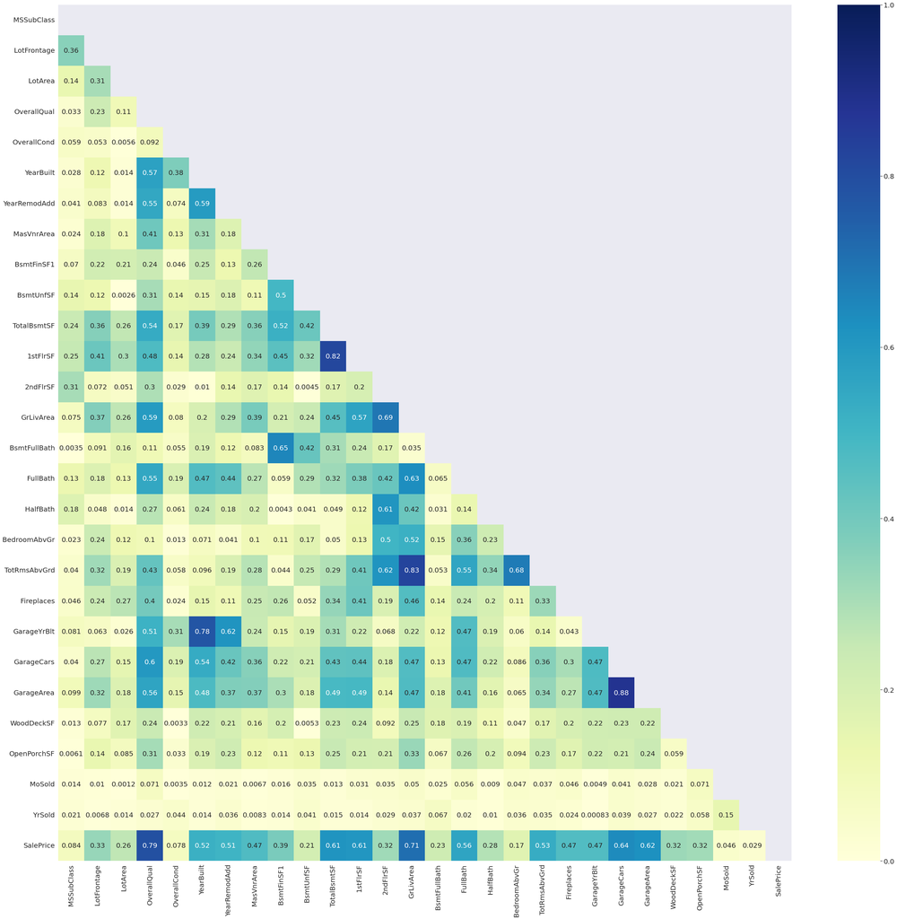

```python
displayHeatMap(df)
```

# **conclusion from the correlations**

Correlation is a statistical measure that describes the association between random variables. It is one of the most widely used statistical concepts. In our case, we can view correlation from two different points of view:

1. **Correlation of features with each other**
2. **Correlation of features with output**
- In the first case, we will tend to drop features that are correlated to each other, since a high correlation between features indicates that the features bring up almost the same information, so it will be a waste of time and a waste of resources to consider such features.

**conclusion : i will drop features that are correlated to each other more then 80%**

- In the second case, we will tend to drop features that are not correlated to the output, since a low correlation between a feature and the output indicates that such feature is not really associatied with output and doesn't contribute much to the final result.

**conclusion : i will drop correlation threshold - 0.045 with 'SalePrice'**

# **Dealing with correlations**

```python
#Drop features that are not correlated with output
D2 = nonCorrelatedWithOutput(df_dummy)
Drop(df_dummy,D2)

#Drop features that are correlated to each other
D1 = FeaturesCorrelatedToEachOther(df_dummy)
Drop(df_dummy,D1)
```

# As we can see , all the data is numeric and full.

# **lets find some outliers !**

**an outlier is a data point that is significantly different from other data points in a data set.**

**It can cause serious problems in statistical analysis. And in the end, detecting and handling outliers is often a somewhat subjective exercise.**

**here is an example graph that shows the amount of values beyond the range, they are our outliers. And we would like to drop them**

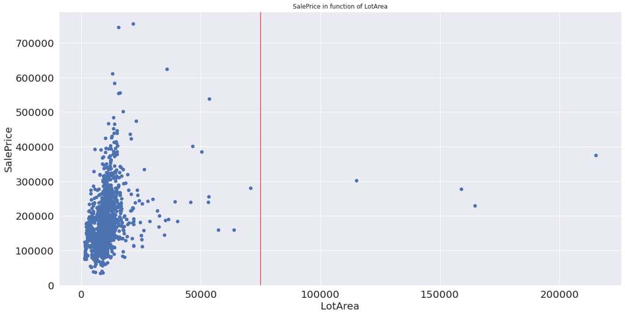

```python
plt.plot(df_dummy['LotArea'], df_dummy['SalePrice'], 'bo')
plt.axvline(x=75000, color='r')
plt.ylabel('SalePrice')
plt.xlabel('LotArea')
plt.title('SalePrice in function of LotArea')
plt.show()
```

```python
z = len(getOutliers(df_dummy))
newDf = DropOutliers(df_dummy)
print(f'as we can see there is 0.08% ({z}) outliers in the data, becuse thats not alot , so i will drop them\n')
print(f'Before the len is :{len(df_dummy)}\n')
print(f'After the len is :{len(newDf)}\n\n')
```

[output not shown]

# Here is the New Data

```python
newDf
```

|  | MSSubClass | LotFrontage | LotArea | OverallQual | OverallCond | YearBuilt | YearRemodAdd | MasVnrArea | BsmtFinSF1 | BsmtUnfSF | ... | KitchenQual_TA | GarageType_BuiltIn | GarageType_CarPort | GarageType_Detchd | GarageFinish_RFn | GarageFinish_Unf | SaleCondition_AdjLand | SaleCondition_Family | SaleCondition_Normal | SaleCondition_Partial |
| --- | --- | --- | --- | --- | --- | --- | --- | --- | --- | --- | --- | --- | --- | --- | --- | --- | --- | --- | --- | --- | --- |
| 0 | 60 | 65.0 | 8450 | 7 | 5 | 2003 | 2003 | 196.0 | 706 | 150 | ... | 0 | 0 | 0 | 0 | 1 | 0 | 0 | 0 | 1 | 0 |
| 1 | 20 | 80.0 | 9600 | 6 | 8 | 1976 | 1976 | 0.0 | 978 | 284 | ... | 1 | 0 | 0 | 0 | 1 | 0 | 0 | 0 | 1 | 0 |
| 2 | 60 | 68.0 | 11250 | 7 | 5 | 2001 | 2002 | 162.0 | 486 | 434 | ... | 0 | 0 | 0 | 0 | 1 | 0 | 0 | 0 | 1 | 0 |
| 3 | 70 | 60.0 | 9550 | 7 | 5 | 1915 | 1970 | 0.0 | 216 | 540 | ... | 0 | 0 | 0 | 1 | 0 | 1 | 0 | 0 | 0 | 0 |
| 4 | 60 | 84.0 | 14260 | 8 | 5 | 2000 | 2000 | 350.0 | 655 | 490 | ... | 0 | 0 | 0 | 0 | 1 | 0 | 0 | 0 | 1 | 0 |
| ... | ... | ... | ... | ... | ... | ... | ... | ... | ... | ... | ... | ... | ... | ... | ... | ... | ... | ... | ... | ... | ... |
| 1455 | 60 | 62.0 | 7917 | 6 | 5 | 1999 | 2000 | 0.0 | 0 | 953 | ... | 1 | 0 | 0 | 0 | 1 | 0 | 0 | 0 | 1 | 0 |
| 1456 | 20 | 85.0 | 13175 | 6 | 6 | 1978 | 1988 | 119.0 | 790 | 589 | ... | 1 | 0 | 0 | 0 | 0 | 1 | 0 | 0 | 1 | 0 |
| 1457 | 70 | 66.0 | 9042 | 7 | 9 | 1941 | 2006 | 0.0 | 275 | 877 | ... | 0 | 0 | 0 | 0 | 1 | 0 | 0 | 0 | 1 | 0 |
| 1458 | 20 | 68.0 | 9717 | 5 | 6 | 1950 | 1996 | 0.0 | 49 | 0 | ... | 0 | 0 | 0 | 0 | 0 | 1 | 0 | 0 | 1 | 0 |
| 1459 | 20 | 75.0 | 9937 | 5 | 6 | 1965 | 1965 | 0.0 | 830 | 136 | ... | 1 | 0 | 0 | 0 | 0 | 0 | 0 | 0 | 1 | 0 |

1335 rows × 97 columns

# Dividing the data

**an important detail:**

If the target variable is skewed or has a wide range of values,

applying np.log to the target variable may help to improve

the performance of certain types of models, by making the data more normally distributed

and reducing the influence of outliers.

**in my project, grid search and other functions will not work without doing that ! (np.log(t))**

```python
t = newDf['SalePrice'].copy()
X = newDf.drop(['SalePrice'], axis=1)
logarithmicT = np.log(t)
```

```python
print(f'X: rows - {len(X)} ,cols - {len(X.columns)}\n\n')
print(f't: rows - {len(t)}\n\n')
print(f'logarithmicT: rows - {len(logarithmicT)}')
```

```
X: rows - 1335 ,cols - 96


t: rows - 1335


logarithmicT: rows - 1335
```

# As we can see

**for the training i need to Normalize my data , but becuse i have some categories features i need to do it on that features only.**

**so i will Normalize only the numeric columns that i didnt dummy encoded.**

- the categories features now as type uint8 (dummy encoded , 0 / 1)
- the other features are float64 or int64

```python
scaler = MinMaxScaler()
notDummey = X.select_dtypes(['float64','int64']).columns
ct = make_column_transformer((scaler,notDummey),remainder = 'passthrough')
transformed_features = X.columns
temp = ct.fit_transform(X)
X = pd.DataFrame(temp,columns=transformed_features)
```

```python
print(f'X: rows - {len(X)} ,cols - {len(X.columns)}\n\n')
print(f't: rows - {len(t)}\n\n')
print(f'logarithmicT: rows - {len(logarithmicT)}')
```

```
X: rows - 1335 ,cols - 96


t: rows - 1335


logarithmicT: rows - 1335
```

# The final data ready for training

```python
print("train data :\n\n")
display(X)
count_empty_values_in_each_column(X)
print("val data:\n\n")
display(t)
print("val data log")
display(logarithmicT)
```

```
train data :
```

|  | MSSubClass | LotFrontage | LotArea | OverallQual | OverallCond | YearBuilt | YearRemodAdd | MasVnrArea | BsmtFinSF1 | BsmtUnfSF | ... | KitchenQual_TA | GarageType_BuiltIn | GarageType_CarPort | GarageType_Detchd | GarageFinish_RFn | GarageFinish_Unf | SaleCondition_AdjLand | SaleCondition_Family | SaleCondition_Normal | SaleCondition_Partial |
| --- | --- | --- | --- | --- | --- | --- | --- | --- | --- | --- | --- | --- | --- | --- | --- | --- | --- | --- | --- | --- | --- |
| 0 | 0.235294 | 0.150685 | 0.033420 | 0.666667 | 0.500 | 0.956204 | 0.883333 | 0.122500 | 0.336832 | 0.064212 | ... | 0.0 | 0.0 | 0.0 | 0.0 | 1.0 | 0.0 | 0.0 | 0.0 | 1.0 | 0.0 |
| 1 | 0.000000 | 0.202055 | 0.038795 | 0.555556 | 0.875 | 0.759124 | 0.433333 | 0.000000 | 0.466603 | 0.121575 | ... | 1.0 | 0.0 | 0.0 | 0.0 | 1.0 | 0.0 | 0.0 | 0.0 | 1.0 | 0.0 |
| 2 | 0.235294 | 0.160959 | 0.046507 | 0.666667 | 0.500 | 0.941606 | 0.866667 | 0.101250 | 0.231870 | 0.185788 | ... | 0.0 | 0.0 | 0.0 | 0.0 | 1.0 | 0.0 | 0.0 | 0.0 | 1.0 | 0.0 |
| 3 | 0.294118 | 0.133562 | 0.038561 | 0.666667 | 0.500 | 0.313869 | 0.333333 | 0.000000 | 0.103053 | 0.231164 | ... | 0.0 | 0.0 | 0.0 | 1.0 | 0.0 | 1.0 | 0.0 | 0.0 | 0.0 | 0.0 |
| 4 | 0.235294 | 0.215753 | 0.060576 | 0.777778 | 0.500 | 0.934307 | 0.833333 | 0.218750 | 0.312500 | 0.209760 | ... | 0.0 | 0.0 | 0.0 | 0.0 | 1.0 | 0.0 | 0.0 | 0.0 | 1.0 | 0.0 |
| ... | ... | ... | ... | ... | ... | ... | ... | ... | ... | ... | ... | ... | ... | ... | ... | ... | ... | ... | ... | ... | ... |
| 1330 | 0.235294 | 0.140411 | 0.030929 | 0.555556 | 0.500 | 0.927007 | 0.833333 | 0.000000 | 0.000000 | 0.407962 | ... | 1.0 | 0.0 | 0.0 | 0.0 | 1.0 | 0.0 | 0.0 | 0.0 | 1.0 | 0.0 |
| 1331 | 0.000000 | 0.219178 | 0.055505 | 0.555556 | 0.625 | 0.773723 | 0.633333 | 0.074375 | 0.376908 | 0.252140 | ... | 1.0 | 0.0 | 0.0 | 0.0 | 0.0 | 1.0 | 0.0 | 0.0 | 1.0 | 0.0 |
| 1332 | 0.294118 | 0.154110 | 0.036187 | 0.666667 | 1.000 | 0.503650 | 0.933333 | 0.000000 | 0.131202 | 0.375428 | ... | 0.0 | 0.0 | 0.0 | 0.0 | 1.0 | 0.0 | 0.0 | 0.0 | 1.0 | 0.0 |
| 1333 | 0.000000 | 0.160959 | 0.039342 | 0.444444 | 0.625 | 0.569343 | 0.766667 | 0.000000 | 0.023378 | 0.000000 | ... | 0.0 | 0.0 | 0.0 | 0.0 | 0.0 | 1.0 | 0.0 | 0.0 | 1.0 | 0.0 |
| 1334 | 0.000000 | 0.184932 | 0.040370 | 0.444444 | 0.625 | 0.678832 | 0.250000 | 0.000000 | 0.395992 | 0.058219 | ... | 1.0 | 0.0 | 0.0 | 0.0 | 0.0 | 0.0 | 0.0 | 0.0 | 1.0 | 0.0 |

1335 rows × 96 columns

```
empty values
------------

val data:
```

```
0       208500
1       181500
2       223500
3       140000
4       250000
         ...
1455    175000
1456    210000
1457    266500
1458    142125
1459    147500
Name: SalePrice, Length: 1335, dtype: int64
```

```
val data log
```

```
0       12.247694
1       12.109011
2       12.317167
3       11.849398
4       12.429216
          ...
1455    12.072541
1456    12.254863
1457    12.493130
1458    11.864462
1459    11.901583
Name: SalePrice, Length: 1335, dtype: float64
```

# Feature Selection

**Now i will :**

**1.make a big function for visultion**

**2. use backwords feature selection in order to decide which features are best to use in our model.**

**3. i will try two model LinearRegression and SGDRegressor and check who gives me the best result**

# note:

**backwords feature selection start from a full set of features and drop features until it reaches the best score.**

**i choose it becuse :**

- It is simple and easy to implement.
- It is relatively fast, since it involves training a model with all the features before pruning them one by one.
- It can help to improve the interpretability of the model by reducing the number of features and making the model simpler.
- It can help to improve the performance of the model by eliminating features that are not useful or contribute noise to the model.

However, it's important to note that backward feature selection is not always the best approach, and it may not work well in all situations. It may be more computationally expensive than other feature selection methods, and it may not always find the optimal set of features for a given problem.

# Next is : **1. make a big function for visultion**

```python
# Required methods:
def find_generator_len(generator, useProgressBar = True):
    i = 0

    if useProgressBar:
        pbar = tqdm(desc = "Calculating Length", ncols = 1000, bar_format = "{desc}{bar:10}{r_bar}")
    for a in generator:
        i += 1
        if useProgressBar:
            pbar.update()

    if useProgressBar:
        pbar.close()

    return i

def get_cv_score_and_loss(x, t, model, k = None, p = None, showGraphs = False, showProgressBar = True):
    resultsDF = pd.DataFrame(columns = ["Fold ID", "Split", "Score", "Loss"])
    cvMethod = ""

    if k is not None:
        cvMethod = "K-Fold"
        cv = KFold(n_splits = k, shuffle = True, random_state = 42)
    elif p is not None:
        cvMethod = f"Leave-{p}-Out"
        cv = LeavePOut(p)
    else:
        raise ValueError("Choose k (for K-Fold) or p (for Leave-P-Out)")

    if showProgressBar:
        pbar = tqdm(desc = "Computing Models", total = find_generator_len(cv.split(x)))

    for i, (trainIDs, validationIDs) in enumerate(cv.split(x)):
        xTrain = x.iloc[trainIDs]
        tTrain = t.iloc[trainIDs]
        xValidation = x.iloc[validationIDs]
        tValidation = t.iloc[validationIDs]
        model.fit(xTrain, tTrain)
        yTrain = model.predict(xTrain)
        yValidation = model.predict(xValidation)
        resultsDF.loc[len(resultsDF)] = [i, "train", model.score(xTrain, tTrain),mean_squared_error(tTrain, yTrain, squared=False)]
        resultsDF.loc[len(resultsDF)] = [i, "validation", model.score(xValidation, tValidation),mean_squared_error(tValidation, yValidation, squared=False)]

        if showProgressBar:
            pbar.update()
    if showProgressBar:
        pbar.close()

    val_resultsDF = resultsDF[resultsDF["Split"] == "validation"]
    train_resultsDF = resultsDF[resultsDF["Split"] == "train"]

    validationScoreMean = val_resultsDF["Score"].mean()
    validationLossMean = val_resultsDF["Loss"].mean()
    trainScoreMean = train_resultsDF["Score"].mean()
    trainLossMean = train_resultsDF["Loss"].mean()

    if showGraphs:
        scoreTitle = f"{k if k is not None else p} {cvMethod} (Score):<br />Mean Validation Score: {validationScoreMean:.2f}<br />Mean Train Score: {trainScoreMean:.2f}"
        lossTitle = f"{k if k is not None else p} {cvMethod} (Loss):<br />Mean Validation Loss: {validationLossMean:.2f}<br />Mean Train Loss: {trainLossMean:.2f}"

        scoreFig = px.line(resultsDF, x = "Fold ID", y = "Score", color = "Split", title = scoreTitle)
        scoreFig.show()

        lossFig = px.line(resultsDF, x = "Fold ID", y = "Loss", color = "Split", title = lossTitle)
        lossFig.show()
```

# Next is :

**2. use backwords feature selection in order to decide which features are best to use in our model.**

# +

**3. check it with SGDRegressor and LinearRegression**

```python
selector_SGD = RFECV(SGDRegressor(random_state=42), cv=RepeatedKFold(n_splits=5, n_repeats=10, random_state=42)).fit(X, t)
X_SGD = X.loc[:, selector_SGD.support_]

selector_LR = RFECV(LinearRegression(), cv=RepeatedKFold(n_splits=5, n_repeats=10, random_state=42)).fit(X, logarithmicT)
X_LR = X.loc[:, selector_LR.support_]
```

# Regularization Techniques

Let's implement regularization by finding out the best combination of penalty and alpha, out of the next possible options:

**2. Alpha (Regularization constant): 0.0001, 0.001, 0.01, 0.1**

**3. Eta0 (Learning rate constant): 0.0001, 0.001, 0.01, 0.1**

i will do that by using GridSearch.

**i checked on the internet and i didnt find any params to play with that can affect the results ..**

the params i found is : {'normalize': [True, False],'fit_intercept': [True, False],'copy_X': [True, False]}

# note :

Alternatively, if learning_rate is set to a value other than "constant",

the eta0 hyperparameter may be used differently during training.

For example, if learning_rate is set to "invscaling",

the eta0 hyperparameter is used to define an inverse scaling factor that is applied to the step size at each iteration.

This can help to reduce the step size over time and fine-tune the model parameters as training progresses.

```python
# train with grid search and get best parameters
def getOptimalHyperParameters(x, t):
    TheReg = SGDRegressor(random_state = 42)
    print(f'For {str(TheReg)} :\n')
    hyperParams = {"penalty": ["l2", "l1", "elasticnet"], "alpha": [0.0001, 0.001, 0.01, 0.1], "eta0": [0.0001, 0.001, 0.01, 0.1]}
    gridSearch = GridSearchCV(TheReg, param_grid = hyperParams).fit(x, t)
    print("Best hyper-parameters:")
    x3,x2,x1 = gridSearch.best_params_["penalty"], gridSearch.best_params_["eta0"],gridSearch.best_params_["alpha"]
    print(f"\teta0: {x2}\n\talpha: {x1}\n\tpenalty: {x3}\n\t")
    return x3,x2,x1
```

now i will check with which model has the highest score with both on validation and train .

```python
bestPenalty0, bestEta0,bestAlpha0 = getOptimalHyperParameters(X_SGD, logarithmicT)
FinalModel0 = SGDRegressor(penalty = bestPenalty0, alpha = bestAlpha0, learning_rate = "constant", eta0 = bestEta0, random_state = 42)
print("SGDRegressor:")
get_cv_score_and_loss(X_SGD, logarithmicT, FinalModel0, k = 10, showGraphs = True)
print("LinearRegression:")
get_cv_score_and_loss(X_LR, logarithmicT, selector_LR, k = 10, showGraphs = True)
```

```
For SGDRegressor(random_state=42) :

Best hyper-parameters:
	eta0: 0.1
	alpha: 0.01
	penalty: elasticnet

SGDRegressor:
```

[interactive chart not shown]

```
LinearRegression:
```

[interactive chart not shown]

# as we can see ..

```
        linear reg:   SGD reg:
```

mean val score:- - - -0.89 - - - - 0.74

mean train score:- - -0.91 - - - - 0.77

mean val loss: - - - -0.12 - - - - 0.18

mean train loss: - - -0.11 - - - - 0.18

its easy to say that the linear reg is way more better , score is high and loss is low. i will try diffent k folds to see maybe the SGDreg could be better .

```python
for i in [j for j in range(40) if j%5 == 0 and j != 0]:
    print(f'\n\tk = {i}\n')
    get_cv_score_and_loss(X_SGD, logarithmicT,FinalModel0, k = i, showGraphs = True)
```

```
	k = 5
```

[interactive chart not shown]

```
	k = 10
```

[interactive chart not shown]

```
	k = 15
```

[interactive chart not shown]

```
	k = 20
```

[interactive chart not shown]

```
	k = 25
```

[interactive chart not shown]

```
	k = 30
```

[interactive chart not shown]

```
	k = 35
```

[interactive chart not shown]

# Cross Validation Conclusions:

It appears that the modle has the highest score with both on validation and train when we do 15-fold CV

# Get ready for submission , Reading and repairing test data

**Now i will make functions that will :**

**1. read the Test Data**

**2.filling and making all data to be numeric**

**3.create a submission**

```python
def readTest1():
    Harta = pd.read_csv("/kaggle/input/task2-dorirose/test.csv")
    Harta.drop(columns = 'Id', axis = 1,inplace = True)
    Harta.replace('', np.NaN, inplace=True)
    return Harta

def getfixedTestData(final_test):
    dropColumnsMoreThen_Nan(final_test)
    tdata_object = final_test.select_dtypes('object').columns
    tdata_numeric = final_test.select_dtypes(['float64','int64']).columns
    all_cols = tdata_object.tolist() + tdata_numeric.tolist()
    fill_na_mean(final_test,tdata_numeric.tolist())
    fill_na_mode(final_test,tdata_object.tolist())
    final_test = pd.get_dummies(final_test, columns=data_object.tolist(), prefix=data_object.tolist(),drop_first = True)
    scaler2 = MinMaxScaler()
    bnotDummey = final_test.select_dtypes(['float64','int64']).columns
    ct = make_column_transformer((scaler2,bnotDummey),remainder = 'passthrough')
    transformed_features = final_test.columns
    temp = ct.fit_transform(final_test)
    Xz = pd.DataFrame(temp,columns=transformed_features)
    return Xz

# Creating a submission file for the competition
def createCSVfile(model,x,theName):
    predicts = model.predict(x)
    submission = pd.read_csv("/kaggle/input/task2-dorirose/sample_submission.csv")
    submission["SalePrice"] = np.exp(predicts.astype(float))
    strx = "submission"+theName+".csv"
    submission.to_csv(strx,index=False)
    print(f'{strx} created !')
```

# Submission

```python
final_test = readTest1()
X = getfixedTestData(final_test)
arrLR = X_LR.columns.tolist()
arrSGD = X_SGD.columns.tolist()

finalTestDataFor_LR = pd.DataFrame(X,columns = arrLR)
finalTestDataFor_SGD = pd.DataFrame(X,columns = arrSGD)
```

```python
createCSVfile(FinalModel0,finalTestDataFor_SGD,'SGDtest')
createCSVfile(selector_LR,finalTestDataForLR,'LRtest')
```

# Some of the other submission

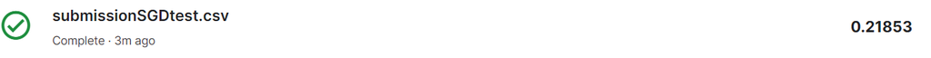

# Best Submission

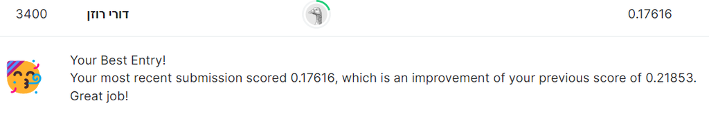

# Contest Summary

In this contest, I attempted to predict the prices of houses in Ames, Iowa. First, I got a visual display about the data in order to obtain details about missing values, correlations,Non correlations and outliers. After filling missing values and dropping expendable ones, I headed for the linear regression and SGD regressor.

note : i used the gridSearch for getting the best params for SGD regressor. i wanted to find which Regularization kind considering also with the alpha and eta0.

I ended up using the - eta0: 0.1 alpha: 0.01 penalty: elasticnet

# references

1. Sixth Practic ML notebook.
2. Seventh Practice ML notebook.
3. "Comprehensive data exploration with Python"- https://www.kaggle.com/code/pmarcelino/comprehensive-data-exploration-with-python